# Bridging the Gap: How SES and Immigrant Status Affect Device Use

Authors

Affiliations

Nathanael Reinertsen

OECD

Clara Wilsher Beyer

IEA Hamburg

Keywords

Large-scale Assessment, Digital Devices, Immigration

## 1 Introduction

It would seem self-evident that socioeconomic status (SES) would affect the how available digital devices are to young people in their out-of-school lives. Additionally, it is widely reported that there are observable relationships between immigrant status and SES. We posit, therefore, that immigrant status may be associated with lower frequency of digital device use, especially outside school hours.

This study explores two international OECD datasets: IELS and PISA 2022. These datasets include information about students immigration status, a wide range or outcomes, as well as information about either the frequency their digital device use, or the daily amount of digital device at and outside of school.

## 2 Aims

Put simply, this research aims to examine the relationship between SES, immigrant status, and digital device by using data from two large-scale assessments. Ultimately, it aims to contribute to discussions on digital inclusion and educational equity, focusing on how socioeconomic status and immigrant status influence digital device utilization among students.

The study utilizes data from two publicly-available OECD data sets: IELS and PISA 2022. Examining both data sets allows for consideration of whether these effects are similar at different points in the life-cycle: IELS measures 5-year-olds and PISA measures 15-year-olds. Both data sets include information on students’ immigration status, SES, and digital device usage.

The research uses correlations and linear regression models to explore the relationships between SES, immigrant status, and digital device use.

## 3 Research Questions

1. Using IELS data, to what extent does Immigrant Status affect frequency of device use in 5-year-olds, over and above SES?
2. Using PISA data, to what extent does Immigrant Status affect access to and use of digital devices for 15-year-olds, over and above ESCS (the PISA index of SES)?
3. Are there general trends that appear to hold across the two age groups, that have implications for policy?

## 4 Literature Review

The so-called Digital Transformation has been shown to impact national economic development. In turn, disparities in access to information and communication technologies can exacerbate existing social inequalities, and limit efforts to alleviate poverty among populations without access to Information and Communication Technologies (e.g. Commission et al. 2024; IEEE 2024; Rozite, Balina, and Freimane 2019; UNESCAP 2021). As we envision education in a digital society, we must necessarily turn our minds to equity and the universality of educational opportunity. This consideration is paramount, as the digital divide not only reflects but also reinforces broader social divides.

In a world where digital literacy is increasingly synonymous with basic literacy, ensuring equitable access to technology becomes a fundamental aspect of educational policy. The integration of digital tools in education offers unprecedented opportunities for personalized learning, interactive engagement, and access to a wealth of resources. However, these benefits are not uniformly distributed. Students from underprivileged backgrounds often face significant barriers, including lack of access to digital devices, which has the potential to limit the development of digital skills. These obstacles can hinder their academic progress and future career prospects, perpetuating cycles of disadvantage.

Previous analyses of data from the Programme for International Student Assessment (PISA) 2022 data indicate a positive correlation between moderate digital device use and academic performance in Mathematics, as well as a sense of belonging (OECD 2023). Given this, it is plausible that factors affecting digital device availability could indirectly impact various educational outcomes. This is additional evidence that device availability is a critical issue for ensuring equitable outcomes for youth.

Published results from the International Early Learning and Child Well-being Study (IELS) (OECD 2020), find that the majority of 5-year-olds use digital devices. This is perhaps unsurprising in itself, but a question remains as to whether there are factors, such as SES and immigrant status that are predictive of device use. Unlike PISA, effects of the frequency of digital device use were more mixed, finding that in the United States and England there were some positive associations between emergent literacy and moderate levels of digital device use (OECD 2020).

## 5 Data

Both IELS and PISA data sets contain a variable coding immigrant status, `IMMIG`. In PISA and IELS, a student is considered an immigrant if both parents were born in a country other than the country of the assessment. PISA further differentiated between first- and second-generation immigrants, where first-generation immigrant students were themselves born outside the country of assessment, while second-generation immigrants were born in the country of assessment.

In IELS, the parents’ questionnaire asks about the frequency with which their child uses a digital device, offering four possible responses: Every Day, Weekly, Monthly, and Rarely or Never. In PISA 2022, students answer about their own use of digital devices, and are asked to estimate how many hours they use a digital device for learning or leisure at school, before and after school, and on weekends. There is also a set of questions about how many of certain types of digital devices there are in their home.

Both IELS and PISA data contain indices of Socio-economic advantage. In IELS this is the `SES` variable, and in PISA it is the `ESCS` variable. The technical reports of each study contain information about how these indices are calculated OECD (2024). It is important to note here, though, that while they are both ways to the same, they are defined differently and measure different things.

## 6 Methods

There were two phases of analysis: a preliminary to establish whether there were likely relationships between relevant variables that were worthy of further analysis; and, a main analysis to examine the nature and strength of the relationships in more detail.

### 6.1 Methods used in Preliminary Analyses

#### 6.1.1 Data Preprocessing

Prior to conducting the analyses, the data were preprocessed to ensure the accuracy and reliability of the results. The preprocessing steps included filtering the datasets to include only the relevant variables for each analysis, and observations with missing values in the variables of interest were dropped.

#### 6.1.2 Survey design and weights

Both IELS and PISA 2022 datasets contain Senate Weights for each observation, that ensure equal contribution of all countries to International analyses. Additionally, balanced replicate weights are provided for the estimation of statistics such as Standard Errors for estimates. All analysis reported in this project use Senate Weights for estimates. An editorial choice has been made to not report Standard Errors of the estimates, but they were computed during analyses.

#### 6.1.3 Effect of SES on Frequency of Device Use

To investigate the relationship between socioeconomic status (SES) and the frequency of digital device use, a one-way ANOVA was conducted. The analysis was performed on a subset of the data, excluding missing values. The SES variable was used as the dependent variable, and the frequency of device use was the independent variable. The analysis was weighted by the sampling weights provided in the dataset. Partial Eta Squared was calculated to measure the effect size of SES on the frequency of device use.

#### 6.1.4 Association of Immigrant Status with Frequency of Device Use

The association between immigrant status and the frequency of digital device use was examined using a Chi-Squared Test. The analysis was conducted on a filtered dataset, excluding missing values. A weighted contingency table was created using the sampling weights, and the Chi-Squared Test was performed on this table. Cramér’s V was calculated to measure the effect size of the association between immigrant status and the frequency of device use.

## 7 Results

### 7.1 Preliminary Analysis

#### 7.1.1 IELS

It is evident that there are far fewer children with immigrant status than natives: overall about 13% of children who sat IELS and for whom there is data on the frequency of their device use, were immigrants. The table below presents the percentage of children in each of the native and immigrant status categories by the frequency of their reported digital device use. In both the native and immigrant groups, the pattern is similar: a large majority (>80%) use devices at least weekly, and a small proportion use digital devices monthly or rarely.

Use of digital devices among five-year-olds by Immigrant Status

|  | Every Day | Weekly | Monthly | Rarely |
| --- | --- | --- | --- | --- |
| Native | 40.2% | 42.2% | 10.8% | 6.9% |
| Immigrant | 47.7% | 40.1% | 7.0% | 5.2% |

Data:  
IELS. OECD, 2020.

A one-way ANOVA analysis was run to examine the contribution of SES to reported frequency of digital device use. With a large sample (n = 4280), statistical significance was expected and, indeed, the p-value approached 0. However, statistical significance is not the same as meaningful difference, so a measure of effect size (Partial Eta Squared) was calculated for the IELS SES index on the reported frequency of digital device use. The effect size measure suggests a large effect.

IELS effect size of SES on frequency of device use

| Variable | n | F_Value | d.f. | P_Value | P.Eta_Squared |
| --- | --- | --- | --- | --- | --- |
| ELPAQ0401 | 4280 | 13.2531 | 3 | 0 | 0.4401 |

Data:  
IELS. OECD, 2020.

Next, the association of Immigrant status (a binary variable in IELS) and reported frequency of digital device use was examined, by performing a Chi Squared Test, followed by calculating a measure of effect size: Cramér’s V. A preliminary analysis with unweighted individual-level data suggested a likely effect, however a second run including weights did not reach the threshold for statistical significance at the .05 level, so the final conclusion is that there is little evidence of an effect from the preliminary analysis.

IELS effect size of IMMIG and frequency of device use

| Variable | n | Chi_Square | Degrees_of_Freedom | P_Value | Cramers_V |
| --- | --- | --- | --- | --- | --- |
| ELPAQ0401 | 4280 | 3.5369 | 3 | 0.316 | 0.0615 |

Data:  
IELS. OECD, 2020.

#### 7.1.2 PISA

In the PISA 2022 data, there is a total of 498453 students for whom there is both data about ESCS and their device use, 486210 students for whom there is both data about their Immigrant status and device use. There are 479448 students for whom there is complete data about their ESCS, their immigrant status and their use of digital devices. The tables below use the filtered data set where there is complete information about Immigrant status, ESCS and Device Use. A preliminary examination of the tables suggests there are similar patterns of frequency of device use for different purposes, across Native, First-Generation and Second-Generation students. However, this is before ESCS is controlled for and further analysis is warranted, given that we suspect ESCS and Immigrant status my interact.

This school year, how many hours/day use digital resources for: learning activities at school

|  | None | Up to 1 hour | 1 to 2 hours | 2 to 3 hours | 3 to 4 hours | 4 to 5 hours | 5 to 6 hours | 6 to 7 hours | More than 7 hours |
| --- | --- | --- | --- | --- | --- | --- | --- | --- | --- |
| Native | 15% | 31% | 21% | 11% | 6% | 5% | 4% | 3% | 4% |
| Second-Generation | 15% | 29% | 20% | 11% | 7% | 6% | 5% | 3% | 4% |
| First-Generation | 14% | 28% | 20% | 11% | 8% | 6% | 5% | 4% | 4% |

Data:  
PISA. OECD, 2022.

This school year, how many hours/day use digital resources for: learning activities before and after school

|  | None | Up to 1 hour | 1 to 2 hours | 2 to 3 hours | 3 to 4 hours | 4 to 5 hours | 5 to 6 hours | 6 to 7 hours | More than 7 hours |
| --- | --- | --- | --- | --- | --- | --- | --- | --- | --- |
| Native | 18% | 31% | 22% | 13% | 7% | 4% | 2% | 1% | 2% |
| Second-Generation | 17% | 28% | 22% | 15% | 8% | 4% | 2% | 1% | 2% |
| First-Generation | 17% | 27% | 22% | 15% | 9% | 5% | 2% | 1% | 2% |

Data:  
PISA. OECD, 2022.

This school year, how many hours/day use digital resources for: learning activities on weekends

|  | None | Up to 1 hour | 1 to 2 hours | 2 to 3 hours | 3 to 4 hours | 4 to 5 hours | 5 to 6 hours | 6 to 7 hours | More than 7 hours |
| --- | --- | --- | --- | --- | --- | --- | --- | --- | --- |
| Native | 23% | 25% | 19% | 13% | 8% | 5% | 3% | 2% | 3% |
| Second-Generation | 22% | 23% | 19% | 14% | 9% | 5% | 3% | 2% | 3% |
| First-Generation | 21% | 22% | 18% | 14% | 10% | 6% | 4% | 2% | 3% |

Data:  
PISA. OECD, 2022.

This school year, how many hours/day use digital resources for: leisure at school

|  | None | Up to 1 hour | 1 to 2 hours | 2 to 3 hours | 3 to 4 hours | 4 to 5 hours | 5 to 6 hours | 6 to 7 hours | More than 7 hours |
| --- | --- | --- | --- | --- | --- | --- | --- | --- | --- |
| Native | 31% | 34% | 16% | 8% | 4% | 2% | 1% | 1% | 2% |
| Second-Generation | 34% | 34% | 15% | 7% | 4% | 2% | 1% | 1% | 2% |
| First-Generation | 36% | 33% | 14% | 7% | 4% | 2% | 1% | 1% | 2% |

Data:  
PISA. OECD, 2022.

This school year, how many hours/day use digital resources for: leisure before and after school

|  | None | Up to 1 hour | 1 to 2 hours | 2 to 3 hours | 3 to 4 hours | 4 to 5 hours | 5 to 6 hours | 6 to 7 hours | More than 7 hours |
| --- | --- | --- | --- | --- | --- | --- | --- | --- | --- |
| Native | 16% | 20% | 15% | 14% | 11% | 8% | 5% | 3% | 6% |
| Second-Generation | 15% | 17% | 15% | 15% | 13% | 9% | 6% | 3% | 6% |
| First-Generation | 17% | 20% | 15% | 14% | 12% | 8% | 5% | 3% | 6% |

Data:  
PISA. OECD, 2022.

This school year, how many hours/day use digital resources for: leisure on weekends

|  | None | Up to 1 hour | 1 to 2 hours | 2 to 3 hours | 3 to 4 hours | 4 to 5 hours | 5 to 6 hours | 6 to 7 hours | More than 7 hours |
| --- | --- | --- | --- | --- | --- | --- | --- | --- | --- |
| Native | 12% | 10% | 9% | 11% | 12% | 10% | 9% | 7% | 20% |
| Second-Generation | 12% | 8% | 8% | 11% | 12% | 11% | 10% | 8% | 20% |
| First-Generation | 13% | 10% | 9% | 11% | 12% | 11% | 10% | 7% | 18% |

Data:  
PISA. OECD, 2022.

Similar approaches were taken to explore the PISA 2022 dataset, as were with the IELS data: ANOVA of ESCS on each of the questionnaire variables related to the use of digital devices for learning and pleasure outside of school hours. The effect size measure (Eta Squared) shows large effects of ESCS on learning activities and leisure activities.

PISA association of ESCS and use of devices for learning and leisure

| Variable | n | F_Value | P_Value | P.Eta_Squared |
| --- | --- | --- | --- | --- |
| Learning activities before/after school | 498453 | 3851.443 | 0 | 0.2659 |
| Learning activities on weekends | 498453 | 2962.287 | 0 | 0.2651 |
| Leisure before/after school | 498453 | 10827.251 | 0 | 0.2729 |
| Leisure on weekends | 498453 | 6851.907 | 0 | 0.2689 |

Data:  
PISA. OECD, 2023.  
<sup>a</sup> With such a large number of cases, P-values are essentially 0

When examining the association of Immigrant Status use of digital devices for learning and leisure outside of school (without controlling for SES), Cramér’s V shows very small associations with learning and leisure activities, however there are a relatively large number of degrees of freedom (which lowers our expectation of the absolute value of Cramér’s V). However, given the general assumption that SES and Immigrant status are connected in some way, the lack of an association between Immigrant Status and use of digital devices at this stage is not necessarily a negative finding, just an indication that SES needs to be controlled for.

PISA association of IMMIG and use of devices for learning and leisure

| Variable | n | Chi_Square | Degrees_of_Freedom | P_Value | Cramers_V |
| --- | --- | --- | --- | --- | --- |
| Learning activities before/after school | 486210 | 28.19851 | 15.95884 | 0 | 0.0053850 |
| Learning activities on weekends | 486210 | 28.46416 | 15.98315 | 0 | 0.0054103 |
| Leisure before/after school | 486210 | 14.79775 | 15.99135 | 0 | 0.0039010 |
| Leisure on weekends | 486210 | 14.38042 | 15.99047 | 0 | 0.0038456 |

### 7.2 Main Analysis

#### 7.2.1 IELS

An analysis was performed to understand the effect of immigrant status on the frequency of digital device use, while controlling for socioeconomic status. An ordinal logistic regression model was fitted using the `svyolr` function of the `Survey` package, with reported frequency of digital device use as the response variable and immigrant Status and IELS SES as predictors. The results of a likelihood ratio chi-square test show the model fits the data acceptably well ($G^2$ = 45.6259081, $df$ =2, $p$ = 0.000).

From the fitted model, predicted probabilities were calculated for different levels of digital device use frequency for native and immigrant groups across the range of socioeconomic status. The graphs below highlight two things. Firstly, that increase in SES is associated with a decrease in the probability of frequent device use. Secondly, that the predicted probability of a child with Immigrant Status being reported to use a digital device at least weekly (first graph), or daily (second graph) is consistently higher across the SES index.

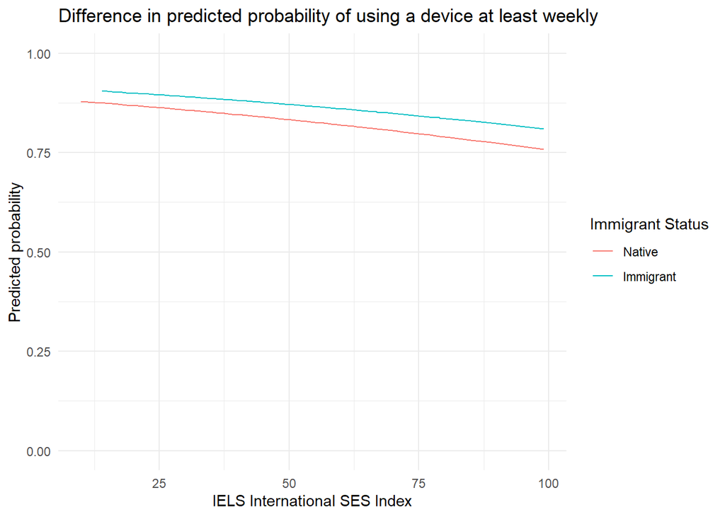

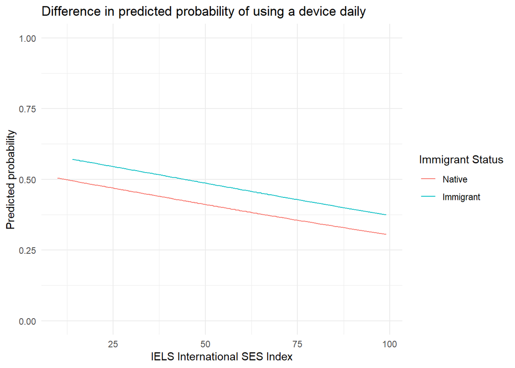

In other words, in the IELS data, having Immigrant Status is predicted to increase the likelihood of frequent digital device use regardless of a child’s socioeconomic status, albeit by only a small amount.

## 9 References

Commission, European, Social Affairs for Employment, Inclusion, N Khabirpour, L Pelizzari, J Limbers, M Richiardi, C Fenwick, C Astarita, and L Westhoff. 2024. *Study on Poverty and Income Inequality in the Context of the Digital Transformation – Final Report. Part a, Ensuring a Socially Fair Digital Transformation*. Publications Office of the European Union. https://doi.org/doi/10.2767/012264.

IEEE. 2024. “Impact of the Digital Divide: Economic, Social, and Educational Consequences.” *Https://Ctu.ieee.org/Impact-of-the-Digital-Divide-Economic-Social-and-Educational-Consequences/*.

OECD. 2020. *Early Learning and Child Well-Being : A Study of Five-Year-Olds in England, Estonia, and the United States*. OECD. https://doi.org/10.1787/3990407f-en.

———. 2021. “International Early Learning and Child Well-Being Study Technical Report.” OECD. https://web-archive.oecd.org/2021-03-30/579643-IELS_2018_Technical_Report%20with%20coverpdf.pdf.

———. 2023. *PISA 2022 Results (Volume II)*. OECD. https://doi.org/10.1787/a97db61c-en.

———. 2024. *PISA 2022 Technical Report*. OECD. https://doi.org/10.1787/01820d6d-en.

Rozite, K, S Balina, and R Freimane. 2019. “Digital Competence Rating and Economic Development in the EU.” In *Proceedings of New Challenges of Economic and Business Development – 2019: Incentives for Sustainable Economic Growth.*, 701–8.

UNESCAP. 2021. “Inequality in Access to Information and Communication Technologies (ICTs) Reducing Inequality in FEALAC Member Countries: Strengthening the Evidence Base to Leave No One Behind.” UNESCAP. https://www.socialprotection-toolbox.org/files/inequality/documents/Inequality_in_Access_to_ICTs.pdf.